# Practice Question 6

# (a) Using read.csv(), load the dataset from AnonymityPoll.csv into a data frame called poll and summarize it with the summary() and str() functions.

`r`r poll <- read.csv(‘AnonymityPoll.csv’) summary(poll)

```
  Internet.Use      Smartphone         Sex           Age                 State           Region
 Min.   :0.0000   Min.   :0.0000   Female:505   Min.   :18.00   California  :103   Midwest  :239
 1st Qu.:1.0000   1st Qu.:0.0000   Male  :497   1st Qu.:37.00   Texas       : 72   Northeast:166
 Median :1.0000   Median :1.0000                Median :55.00   New York    : 60   South    :359
 Mean   :0.7742   Mean   :0.5078                Mean   :52.37   Pennsylvania: 45   West     :238
 3rd Qu.:1.0000   3rd Qu.:1.0000                3rd Qu.:66.00   Florida     : 42
 Max.   :1.0000   Max.   :1.0000                Max.   :96.00   Ohio        : 38
 NA's   :1        NA's   :43                    NA's   :27      (Other)     :642
 Conservativeness Info.On.Internet Worry.About.Info Privacy.Importance Anonymity.Possible
 Min.   :1.000    Min.   : 0.000   Min.   :0.0000   Min.   :  0.00     Min.   :0.0000
 1st Qu.:3.000    1st Qu.: 2.000   1st Qu.:0.0000   1st Qu.: 41.43     1st Qu.:0.0000
 Median :3.000    Median : 4.000   Median :0.0000   Median : 68.75     Median :0.0000
 Mean   :3.277    Mean   : 3.795   Mean   :0.4886   Mean   : 62.85     Mean   :0.3692
 3rd Qu.:4.000    3rd Qu.: 6.000   3rd Qu.:1.0000   3rd Qu.: 88.89     3rd Qu.:1.0000
 Max.   :5.000    Max.   :11.000   Max.   :1.0000   Max.   :100.00     Max.   :1.0000
 NA's   :62       NA's   :210      NA's   :212      NA's   :215        NA's   :249
 Tried.Masking.Identity Privacy.Laws.Effective
 Min.   :0.0000         Min.   :0.0000
 1st Qu.:0.0000         1st Qu.:0.0000
 Median :0.0000         Median :0.0000
 Mean   :0.1633         Mean   :0.2617
 3rd Qu.:0.0000         3rd Qu.:1.0000
 Max.   :1.0000         Max.   :1.0000
 NA's   :218            NA's   :108
```

`r`r str(poll)

```
'data.frame':   1002 obs. of  13 variables:
 $ Internet.Use          : int  1 1 0 1 0 1 1 0 0 1 ...
 $ Smartphone            : int  0 0 1 0 NA 1 0 0 NA 0 ...
 $ Sex                   : Factor w/ 2 levels \Female\,\Male\: 2 2 1 2 1 2 1 1 2 1 ...
 $ Age                   : int  62 45 70 70 80 49 52 76 75 76 ...
 $ State                 : Factor w/ 49 levels \Alabama\,\Arizona\,..: 20 39 29 10 10 41 21 31 32 32 ...
 $ Region                : Factor w/ 4 levels \Midwest\,\Northeast\,..: 2 3 2 3 3 3 1 2 3 3 ...
 $ Conservativeness      : int  4 1 4 4 4 4 3 3 4 4 ...
 $ Info.On.Internet      : int  0 1 0 3 NA 6 3 NA NA 0 ...
 $ Worry.About.Info      : int  1 0 0 1 NA 0 1 NA NA 0 ...
 $ Privacy.Importance    : num  100 0 NA 88.9 NA ...
 $ Anonymity.Possible    : int  0 1 0 1 NA 1 0 NA NA 1 ...
 $ Tried.Masking.Identity: int  0 0 0 0 NA 1 0 NA NA 0 ...
 $ Privacy.Laws.Effective: int  0 1 NA 0 NA 0 1 NA 0 1 ...
```

## How many people participated in the poll?

1002

# (b) Look at the breakdown of the number of people with smartphones using the table() command on the Smartphone variable.

`r`r table(poll$Smartphone)

```
  0   1
472 487
```

## How many interviewees responded that they use a smartphone?

487

## How many interviewees responded that they don???t use a smartphone?

472

## How many interviewees did not respond to the question, resulting in a missing value, or NA, in the summary() output?

43

# (c) Look at the breakdown of the number of people with smartphones and Internet use using the table() command.

`r`r table(poll$Smartphone, poll$Internet.Use)

```
      0   1
  0 186 285
  1  17 470
```

## How many interviewees reported not having used the Internet and not having used a smartphone?

186

## How many interviewees reported having used the Internet and having used a smart- phone?

470

## How many interviewees reported having used the Internet but not having used a smartphone?

285

## How many interviewees reported having used a smartphone but not having used the Internet?

17

# (d) Many of the response variables (Info.On.Internet, Worry.About.Info, Privacy.Importance, Anonymity.Possible, and Tried.Masking.Identity) were not collected if an interviewee does not use the Internet or a smartphone, meaning the variables will have missing values for these interviewees.

`r`r sum(is.na(poll$Internet.Use))

```
[1] 1
```

`r`r sum(is.na(poll$Smartphone))

```
[1] 43
```

## How many interviewees have a missing value for their Internet use?

1

## How many interviewees have a missing value for their smartphone use?

43

# (e) Use the subset function to obtain a data frame called ???limited???, which is limited to interviewees who reported Internet use or who reported smartphone use.

`r`r limited <- subset(poll, Internet.Use == 1 | Smartphone == 1) str(limited)

```
'data.frame':   792 obs. of  13 variables:
 $ Internet.Use          : int  1 1 0 1 1 1 1 1 1 1 ...
 $ Smartphone            : int  0 0 1 0 1 0 0 1 1 0 ...
 $ Sex                   : Factor w/ 2 levels \Female\,\Male\: 2 2 1 2 2 1 1 1 1 2 ...
 $ Age                   : int  62 45 70 70 49 52 76 50 47 69 ...
 $ State                 : Factor w/ 49 levels \Alabama\,\Arizona\,..: 20 39 29 10 41 21 32 45 32 31 ...
 $ Region                : Factor w/ 4 levels \Midwest\,\Northeast\,..: 2 3 2 3 3 1 3 3 3 2 ...
 $ Conservativeness      : int  4 1 4 4 4 3 4 3 3 3 ...
 $ Info.On.Internet      : int  0 1 0 3 6 3 0 1 0 9 ...
 $ Worry.About.Info      : int  1 0 0 1 0 1 0 0 0 0 ...
 $ Privacy.Importance    : num  100 0 NA 88.9 88.9 ...
 $ Anonymity.Possible    : int  0 1 0 1 1 0 1 0 1 0 ...
 $ Tried.Masking.Identity: int  0 0 0 0 1 0 0 0 0 0 ...
 $ Privacy.Laws.Effective: int  0 1 NA 0 0 1 1 0 0 0 ...
```

## How many interviewees are in the new data frame?

792

# (f) For all the remaining questions use the limited data frame you have created.

`r`r summary(is.na(limited))

```
 Internet.Use    Smartphone         Sex             Age            State           Region
 Mode :logical   Mode :logical   Mode :logical   Mode :logical   Mode :logical   Mode :logical
 FALSE:792       FALSE:772       FALSE:792       FALSE:770       FALSE:792       FALSE:792
                 TRUE :20                        TRUE :22
 Conservativeness Info.On.Internet Worry.About.Info Privacy.Importance Anonymity.Possible
 Mode :logical    Mode :logical    Mode :logical    Mode :logical      Mode :logical
 FALSE:747        FALSE:792        FALSE:790        FALSE:787          FALSE:753
 TRUE :45                          TRUE :2          TRUE :5            TRUE :39
 Tried.Masking.Identity Privacy.Laws.Effective
 Mode :logical          Mode :logical
 FALSE:784              FALSE:727
 TRUE :8                TRUE :65
```

## Which variables have missing values in the limited data frame?

Smartphone, Age, Conservativeness, Worry.About.Info, Privacy.Importance, Anonymity.Possible, Tried.Masking.Identity, Privacy.Laws.Effective

# (g) What is the average number of pieces of personal information on the Internet, according to the Info.On.Internet variable?

`r`r mean(limited$Info.On.Internet)

```
[1] 3.795455
```

# (h) How many interviewees reported a value of 0 for Info.On.Internet? How many interviewees reported the maximum value of 11 for Info.On.Internet?

`r`r sum(limited$Info.On.Internet == 0)

```
[1] 105
```

`r`r sum(limited$Info.On.Internet == 11)

```
[1] 8
```

# (i) What proportion of interviewees who answered the Worry.About.Info question worry about how much information is available about them on the Internet?

`r`r mean(limited$Worry.About.Info, na.rm = TRUE)

```
[1] 0.4886076
```

# (j) What proportion of interviewees who answered the Anonymity.Possible question think it is possible to be completely anonymous on the Internet?

`r`r mean(limited$Anonymity.Possible, na.rm = TRUE)

```
[1] 0.3691899
```

# (k) Build a histogram of the age of interviewees.

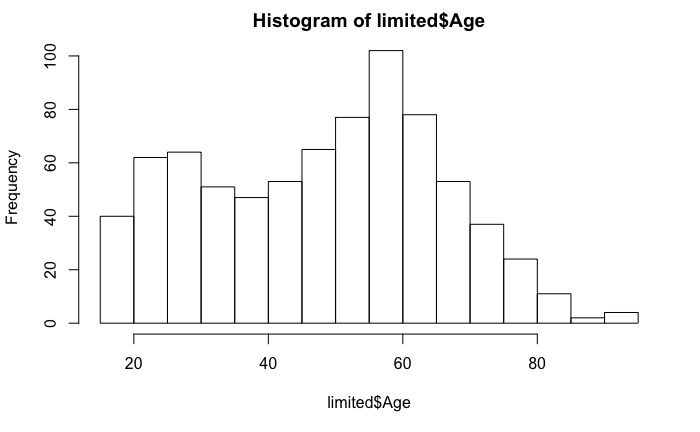

## What is the best represented age group in the population - people aged around 20, people aged around 40, people aged around 60, people aged around 80?

60

# (l) Both Age and Info.On.Internet are variables that take on many values, so a good way to observe their relationship is through a graph. However, because Info.On.Internet takes on a small number of values, multiple points can be plotted in exactly the same location on this graph using the plot() function.

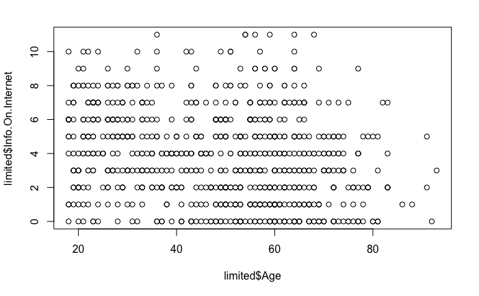

## What is the largest number of interviewees that have exactly the same value in their Age variable and the same value in their Info.On.Internet variable?

`r`r max(table(limited$Info.On.Internet, limited$Age))

```
[1] 6
```

# (m) To avoid points covering each other up, we can use the jitter() function on the values we pass to the plot function. Experimenting with the command jitter(c(1, 2, 3)), what appears to be the functionality of the jitter command?

`r`r jitter(c(1, 2, 3))

```
[1] 0.8765991 1.8737806 2.8082996
```

It adds slight noise to a given noise which will allow us to see the overlapping data as in the case of the plot in (l).

# (n) Now, plot Age against Info.On.Internet with plot(jitter(limited$Age), jitter(limited$Info.On.Internet)). Comment on the relationship you observe between Age and Info.On.Internet?

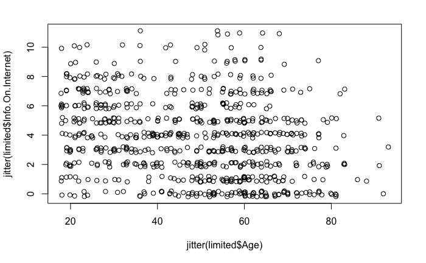

Younger people tend to have more information of theirs on the internet as opposed to the older people. This indicates a negative correlation between age and information on the internet.

# (o) Use the tapply() function to find the average of the Info.On.Internet value, depending on whether an interviewee is a smartphone user or not?

`r`r tapply(limited$Info.On.Internet, limited$Smartphone == 1, mean)

```
   FALSE     TRUE
2.922807 4.367556
```

# (p) Similarly use tapply to break down the Tried.Masking.Identity variable for smartphone and non-smartphone users.

`r`r tapply(limited$Tried.Masking.Identity, limited$Smartphone == 1, table)

```
$`FALSE`

  0   1
248  33

$`TRUE`

  0   1
390  93
```